# Climatevars_all sites_all years_all timeframes

JR Gremer

2025-07-23

# This code compiles and calculates all flint and bioclim variables for each site, year, and timeframe

Note: Due to changes to how bioclim is calculated for water year and how the growing season months are calculated in this script, we will have to update:

- Climate data methods in the manuscript
- Climate variable correlations (Figure S1)
- Climate PCAs currently in the manuscript (Figure 1, S2; Table S2, S3)
- Climate distance calculations (Figure S3; Table S4)
- Fitness ~ climate distance regressions and figures (Figure 2-4; S4-S7; Table 1-2)

## Load libraries

```r
library(raster) #for the CV function
library(tidyverse)
sem <- function(x, na.rm=FALSE) { #standard error function
  sd(x,na.rm=na.rm)/sqrt(length(na.omit(x)))
}

true_round <- function(number, digits) { #rounding function that bypasses R's round to even default
  posneg <- sign(number)
  number <- abs(number) * 10^digits
  number <- number + 0.5 + sqrt(.Machine$double.eps)
  number <- trunc(number)
  number <- number / 10 ^ digits
  number * posneg
}
```

## Load the pop and location data

```r
#pop info
pops_common_garden <- read_csv("../input/WL2_Data/Pops_for_2023_WL2.csv") #pops included in common garden
pops_common_garden_nonotes <- pops_common_garden %>% select(parent.pop:phylogroup, elevation.group) #subset columns

#Need to add YO1 for JGI:
yose1 <- tibble(parent.pop="YO1", phylogroup=NA)
pops_common_garden_jgi <- bind_rows(pops_common_garden_nonotes, yose1)

#extra location info
pop_loc <- read_csv("../input/Strep_tort_locs.csv")
#need to change YOSE to YO
pop_loc_yo <- pop_loc %>% mutate(parent.pop = str_replace(`Site code`, "YOSE(\\d+)", "YO\\1")) %>% select(Lat, Long, elev_m=`Elevation (m)`, parent.pop)

#merge in location info
pop_elev <- left_join(pops_common_garden_jgi, pop_loc_yo)
#add in common garden sites
sites_loc <- tibble(parent.pop=c("UCD_Garden", "WL2_Garden"), phylogroup=NA, Lat=c("38.53250", "38.82599"), Long=c("-121.78299", "-120.25090"), elev_m=c(16,2020))
pops_gardens_locs <- bind_rows(pop_elev, sites_loc)

#add row names
pops_gardens_locs_rowids <- pops_gardens_locs %>% rowid_to_column() %>% mutate(rowid = as.character(rowid))
```

## Load raw flint data

```r
flint_data1 <- read_csv("../input/Updated_Flint_Climate_Oct2024.csv") #This only goes through Aug 2024
flint_data2 <- read_csv("../input/Updated_Flint_Sept-Dec2024.csv") #Sept-Dec 2024
#merge:
flint_data <- bind_rows(flint_data1, flint_data2)
```

## Convert raw flint into a workable format (original code in “Climate_Shapefile.Rmd”)

```r
cwd <- flint_data %>% filter(str_detect(DataFileName, "cwd"))
cwd_long <- cwd %>%
  pivot_longer(!DataFileName, names_to = "rowid", values_to = "cwd") %>%
  extract(DataFileName, c("year", "month"), "(\\d+)(.*)", convert = TRUE) %>%
  separate(month, into = c("month", "file_type")) %>% select(rowid, year, month, cwd)

pet <- flint_data %>% filter(str_detect(DataFileName, "pet"))
pet_long <- pet %>%
  pivot_longer(!DataFileName, names_to = "rowid", values_to = "pet") %>%
  extract(DataFileName, c("year", "month"), "(\\d+)(.*)", convert = TRUE) %>%
  separate(month, into = c("month", "file_type")) %>% select(rowid, year, month, pet)

aet <- flint_data %>%
  filter(str_detect(DataFileName, "aet"))
aet_long <- aet %>%
  pivot_longer(!DataFileName, names_to = "rowid", values_to = "aet") %>%
  extract(DataFileName, c("year", "month"), "(\\d+)(.*)", convert = TRUE) %>%
  separate(month, into = c("month", "file_type")) %>% select(rowid, year, month, aet)

pck <- flint_data %>% filter(str_detect(DataFileName, "pck"))
pck_long <- pck %>%
  pivot_longer(!DataFileName, names_to = "rowid", values_to = "pck") %>%
  extract(DataFileName, c("year", "month"), "(\\d+)(.*)", convert = TRUE) %>%
  separate(month, into = c("month", "file_type")) %>% select(rowid, year, month, pck)

ppt <- flint_data %>% filter(str_detect(DataFileName, "ppt"))
ppt_long <- ppt %>%
  pivot_longer(!DataFileName, names_to = "rowid", values_to = "ppt") %>%
  extract(DataFileName, c("year", "month"), "(\\d+)(.*)", convert = TRUE) %>%
  separate(month, into = c("month", "file_type")) %>% select(rowid, year, month, ppt)

tmn <- flint_data %>% filter(str_detect(DataFileName, "tmn"))
tmn_long <- tmn %>%
  pivot_longer(!DataFileName, names_to = "rowid", values_to = "tmn") %>%
  extract(DataFileName, c("year", "month"), "(\\d+)(.*)", convert = TRUE) %>%
  separate(month, into = c("month", "file_type")) %>% select(rowid, year, month, tmn)

tmx <- flint_data %>% filter(str_detect(DataFileName, "tmx"))
tmx_long <- tmx %>%
  pivot_longer(!DataFileName, names_to = "rowid", values_to = "tmx") %>%
  extract(DataFileName, c("year", "month"), "(\\d+)(.*)", convert = TRUE) %>%
  separate(month, into = c("month", "file_type")) %>% select(rowid, year, month, tmx)

#merge:
flint_long <- full_join(aet_long, cwd_long)
flint_long <- full_join(flint_long, pck_long)
flint_long <- full_join(flint_long, pet_long)
flint_long <- full_join(flint_long, ppt_long)
flint_long <- full_join(flint_long, tmn_long)
flint_long <- full_join(flint_long, tmx_long)
flint_pops <- full_join(pops_gardens_locs_rowids, flint_long)
write_csv(flint_pops, "../output/Climate/Flint_AllSites_Dec2024.csv")
```

Note: flint_pops includes the 2 common garden sites

### Subset to only the 23 pops plus the garden sites

```r
pop_elev_climate <- flint_pops %>%
  select(parent.pop, elevation.group, elev_m, Lat:Long, year:tmx) %>% #organize the columns
  mutate(elevation.group=if_else(parent.pop=="UCD_Garden", "Low",  #add elevation group for gardens
                                 if_else(parent.pop=="WL2_Garden", "High", elevation.group))) %>%
  filter(parent.pop!="YO1") #remove YO1 from the dataset
write_csv(pop_elev_climate, "../output/Climate/flint_climate_UCDpops.csv") #this is the file used in "Flint_Growth_Season.Rmd" and "Climate_PCAs_AllYear.Rmd"
```

## Flint Water Year

```r
month_nums <- tibble(month=c("jan","feb","mar","apr","may","jun","jul","aug","sep","oct","nov","dec"),
                     month_nums=c(1:12)) #give calendar months a number

#merge:
flint_all_year_mosnums <- left_join(pop_elev_climate, month_nums) %>% arrange(parent.pop, year, month_nums)
```

```r
#define the water year as November-October:
flint_all_year_wtr_yr <- flint_all_year_mosnums %>%
  mutate(wtr_yr = year + month_nums %in% c(11:12)) %>%
  mutate(timeframe = case_when(
                                wtr_yr < 1964 ~ "beforehistoric",
                                wtr_yr >= 1964 & wtr_yr < 1994 ~ "historic",
                                wtr_yr >= 1994 & wtr_yr < 2024 ~ "recent",
                                wtr_yr == 2024 ~ "2024")) %>%
                         mutate(timeframe = as.factor(timeframe), month = as.factor(month)) %>%
                         filter(wtr_yr != 1895) %>% #remove years with less than 12 months of data
  filter(if_else(parent.pop!="WL2_Garden", wtr_yr<2024, wtr_yr<=2024)) %>% #Since the home sites climate ends in 2023, need to keep 2024 for the garden (for climate distance comparisons)
                         mutate(months_wtryr = case_when(
                           month == "nov" ~ 1,
                           month == "dec" ~ 2,
                           month == "jan" ~ 3,
                           month == "feb" ~ 4,
                           month == "mar" ~ 5,
                           month == "apr" ~ 6,
                           month == "may" ~ 7,
                           month == "jun" ~ 8,
                           month == "jul" ~ 9,
                           month == "aug" ~ 10,
                           month == "sep" ~ 11,
                           month == "oct" ~ 12 )) %>%
  select(parent.pop:month, timeframe, wtr_yr, months_wtryr, aet:tmx)  #organize the columns
summary(flint_all_year_wtr_yr)
```

```
##   parent.pop        elevation.group        elev_m           Lat
##  Length:38412       Length:38412       Min.   :  16.0   Length:38412
##  Class :character   Class :character   1st Qu.: 748.9   Class :character
##  Mode  :character   Mode  :character   Median :1934.5   Mode  :character
##                                        Mean   :1599.3
##                                        3rd Qu.:2353.6
##                                        Max.   :2872.3
##
##      Long                year          month                timeframe
##  Length:38412       Min.   :1895   apr    : 3201   2024          :   12
##  Class :character   1st Qu.:1927   aug    : 3201   beforehistoric:20400
##  Mode  :character   Median :1959   dec    : 3201   historic      : 9000
##                     Mean   :1959   feb    : 3201   recent        : 9000
##                     3rd Qu.:1991   jan    : 3201
##                     Max.   :2024   jul    : 3201
##                                    (Other):19206
##      wtr_yr      months_wtryr        aet              cwd
##  Min.   :1896   Min.   : 1.00   Min.   :  0.00   Min.   :  0.00
##  1st Qu.:1928   1st Qu.: 3.75   1st Qu.:  5.10   1st Qu.: 25.07
##  Median :1960   Median : 6.50   Median : 19.61   Median : 46.70
##  Mean   :1960   Mean   : 6.50   Mean   : 33.11   Mean   : 55.27
##  3rd Qu.:1992   3rd Qu.: 9.25   3rd Qu.: 53.75   3rd Qu.: 80.57
##  Max.   :2024   Max.   :12.00   Max.   :208.40   Max.   :213.40
##
##       pck              pet              ppt               tmn
##  Min.   :   0.0   Min.   :  7.80   Min.   :   0.00   Min.   :-20.210
##  1st Qu.:   0.0   1st Qu.: 35.60   1st Qu.:   8.83   1st Qu.: -2.730
##  Median :   0.0   Median : 81.00   Median :  49.87   Median :  2.530
##  Mean   : 143.4   Mean   : 88.38   Mean   :  97.49   Mean   :  2.539
##  3rd Qu.: 119.1   3rd Qu.:134.60   3rd Qu.: 137.87   3rd Qu.:  7.570
##  Max.   :2598.1   Max.   :214.20   Max.   :1244.49   Max.   : 21.350
##
##       tmx
##  Min.   :-6.88
##  1st Qu.: 9.17
##  Median :15.52
##  Mean   :16.25
##  3rd Qu.:22.71
##  Max.   :39.76
##
```

```r
write_csv(flint_all_year_wtr_yr, "../output/Climate/flint_all_year_wtr_yr.csv")

#water year is calculated Nov - October.  Could have issues with this, but move forward for now. Can be changed later.
```

## Bioclim water year calculations

Note: Changed this from using the calc_biovars function in the QBMS package to calculating by hand to match the growing season calculations. Referenced this r code: https://github.com/rspatial/dismo/blob/master/R/biovars.R

```r
# Calculating average temp and diurnal range for each month
bioclim_wtr_yr_prep <- flint_all_year_wtr_yr %>%
  mutate(tavg = (tmn + tmx)/2, t_diurnal = (tmx-tmn))

#Bio 1, 2, 4, 7, 12, 15
bioclim_wtr_yr_calc <- bioclim_wtr_yr_prep %>%
  group_by(parent.pop, elevation.group, elev_m, timeframe, wtr_yr) %>%
  summarise(ann_tmean=mean(tavg),  #Bio1 - Annual Mean Temperature
            mean_diurnal_range=mean(t_diurnal), #Bio2 - Mean Diurnal Range
            temp_seasonality=sd(tavg), #Bio4 - Temperature Seasonality
            temp_ann_range=(max(tmx))-(min(tmn)), #bio7 - temp annual range
            ann_ppt=sum(ppt), #bio12 - annual precip
            ppt_seasonality=cv(ppt+1)) #bio15 - Precipitation Seasonality (+1 to avoid strange CVs for areas where mean rainfaill is < 1)
```

```
## 'timeframe'. You can override using the `.groups` argument.
```

```r
# Calculating wettest, driest, warmest, and coldest months
wettest_month <- bioclim_wtr_yr_prep %>%  #there's one wettest month per pop/year
  group_by(parent.pop, elevation.group, elev_m, timeframe, wtr_yr) %>%
  slice_max(ppt)
driest_month <- bioclim_wtr_yr_prep %>%  #there's more than one driest month for some pops and years
  group_by(parent.pop, elevation.group, elev_m, timeframe, wtr_yr) %>%
  slice_min(ppt)
warmest_month <- bioclim_wtr_yr_prep %>% #there's more than one warmest month for 1 pop/year
  group_by(parent.pop, elevation.group, elev_m, timeframe, wtr_yr) %>%
  slice_max(tavg)
coldest_month <- bioclim_wtr_yr_prep %>% #there's more than one driest month for some pops and years
  group_by(parent.pop, elevation.group, elev_m, timeframe, wtr_yr) %>%
  slice_min(tavg)

# Bio 8, 9, 18, 19
bio8_wtryr <- wettest_month %>% #bio8 = tmean_wettest_month
  dplyr::select(parent.pop, elevation.group, elev_m, timeframe, wtr_yr, tmean_wettest_month=tavg)
bio9_wtryr <- driest_month %>% #bio9 = tmean_driest_month
  group_by(parent.pop, elevation.group, elev_m, timeframe, wtr_yr) %>%
  summarise(tmean_driest_month=mean(tavg)) #taking the average b/c some years where there are multiple driest months
```

```
## 'timeframe'. You can override using the `.groups` argument.
```

```r
bio18_wtryr <- warmest_month %>% #bio18 = ppt_warmest_month
  group_by(parent.pop, elevation.group, elev_m, timeframe, wtr_yr) %>%
  summarise(ppt_warmest_month=mean(ppt)) #taking the avg b/c more than one warmest month for one pop/year
```

```
## 'timeframe'. You can override using the `.groups` argument.
```

```r
bio19_wtryr <- coldest_month %>% #bio19 = ppt_coldest_month
  group_by(parent.pop, elevation.group, elev_m, timeframe, wtr_yr) %>%
  summarise(ppt_coldest_month=mean(ppt)) #taking the avg b/c more than one coldest month for one pop/year
```

```
## 'timeframe'. You can override using the `.groups` argument.
```

```r
#merge:
bio8_9_wtryr <- full_join(bio8_wtryr, bio9_wtryr)
```

```
## wtr_yr)`
```

```r
bio18_19_wtryr <- full_join(bio18_wtryr, bio19_wtryr)
```

```
## wtr_yr)`
```

```r
all_periods_wtryr <- full_join(bio8_9_wtryr, bio18_19_wtryr)
```

```
## wtr_yr)`
```

```r
#Merge all bioclims
bioclim_wtryr <- full_join(bioclim_wtr_yr_calc, all_periods_wtryr)
```

```
## wtr_yr)`
```

```r
summary(bioclim_wtryr)
```

```
##   parent.pop        elevation.group        elev_m                timeframe
##  Length:3201        Length:3201        Min.   :  16.0   2024          :   1
##  Class :character   Class :character   1st Qu.: 748.9   beforehistoric:1700
##  Mode  :character   Mode  :character   Median :1934.5   historic      : 750
##                                        Mean   :1599.3   recent        : 750
##                                        3rd Qu.:2353.6
##                                        Max.   :2872.3
##      wtr_yr       ann_tmean       mean_diurnal_range temp_seasonality
##  Min.   :1896   Min.   : 0.5342   Min.   : 9.548     Min.   :5.059
##  1st Qu.:1928   1st Qu.: 5.5175   1st Qu.:12.781     1st Qu.:6.192
##  Median :1960   Median : 8.5587   Median :13.691     Median :6.619
##  Mean   :1960   Mean   : 9.3921   Mean   :13.706     Mean   :6.610
##  3rd Qu.:1992   3rd Qu.:13.8158   3rd Qu.:14.533     3rd Qu.:6.988
##  Max.   :2024   Max.   :18.0538   Max.   :18.652     Max.   :8.346
##  temp_ann_range     ann_ppt       ppt_seasonality  tmean_wettest_month
##  Min.   :25.91   Min.   : 145.6   Min.   : 58.96   Min.   :-10.330
##  1st Qu.:31.14   1st Qu.: 807.8   1st Qu.:100.08   1st Qu.: -1.260
##  Median :32.55   Median :1090.4   Median :114.11   Median :  2.010
##  Mean   :32.72   Mean   :1169.9   Mean   :115.38   Mean   :  2.602
##  3rd Qu.:34.08   3rd Qu.:1463.2   3rd Qu.:128.00   3rd Qu.:  6.655
##  Max.   :42.90   Max.   :3545.7   Max.   :226.46   Max.   : 17.080
##  tmean_driest_month ppt_warmest_month ppt_coldest_month
##  Min.   :-4.845     Min.   : 0.000    Min.   :  0.01
##  1st Qu.:13.410     1st Qu.: 0.000    1st Qu.:100.20
##  Median :17.070     Median : 0.900    Median :182.05
##  Mean   :17.399     Mean   : 6.246    Mean   :217.84
##  3rd Qu.:22.370     3rd Qu.: 7.710    3rd Qu.:303.06
##  Max.   :29.065     Max.   :88.960    Max.   :951.79
```

```r
write_csv(bioclim_wtryr, "../output/Climate/bioclim_wtr_yr.csv")
```

Note: bioclim_wtryr includes the 2 common garden sites

## Calculate Growing Season Months

Note: Originally calculated this separately for recent and historical time periods and then averaged the grow months. Here, use 60 years summary stats for the calcs, but keep individual yearly growth seasons (don’t average grow months)

- Take the max end date and min start date for the years without one
- Get a yearly value for the length of the growth season

Adapted from Brandie’s Flint_Growth_Season.Rmd

### Prelim Calcs

```r
growyear_months <- tibble(month=c(1:12), growmonth=c(5, 6, 7, 8, 9, 10, 11, 12, 1, 2, 3, 4)) #start in Sept for low elev though due to after-ripening requirements
pop_elev_climate_60 <- pop_elev_climate %>%
  filter(parent.pop != "UCD_Garden") %>% #remove Davis garden
  mutate(month = recode(month, #convert months to numbers
  jan = 1,
  feb = 2,
  mar = 3,
  apr = 4,
  may = 5,
  jun = 6,
  jul = 7,
  aug = 8,
  sep = 9,
  oct = 10,
  nov = 11,
  dec = 12
)) %>%
  left_join(growyear_months) %>%
  mutate(grow_yr = year + month %in% c(9:12)) %>% #match grow year to grow months
  filter(grow_yr >= 1964, grow_yr < 2024) %>%  #use the most recent 60 years
  select(parent.pop:Long, year_cal=year, grow_yr, month, growmonth, cwd, pck, ppt, tmn, tmx) %>%
  arrange(parent.pop, year_cal, month)
pop_elev_climate_60_avgs <- pop_elev_climate_60 %>%
  group_by(parent.pop, elevation.group, elev_m,  Lat, Long, month) %>%
  summarise_at(c("cwd", "pck", "ppt", "tmn", "tmx"), c(mean, sem), na.rm = TRUE) #60 year averages per month for each pop
names(pop_elev_climate_60_avgs) <- gsub("fn2", "sem", colnames(pop_elev_climate_60_avgs))
names(pop_elev_climate_60_avgs) <-gsub("fn1", "mean", colnames(pop_elev_climate_60_avgs))
pop_elev_climate_60_avgs <- pop_elev_climate_60_avgs %>% mutate(PckSum=sum(pck_mean)) #estimate of average total snowpack in a year
```

### Populations that get less than 70 mm (b/c that’s the avg height in Oct at WL2 garden) of snow pack in a year (on average)

- First month = ppt >= 25
  - Remember this month is not included in the final “growth season”
  - Jenny has used 25 mm as germinating inducing rain (esp b/c it’s a sum of ppt for the whole month), 10 mm would probably be fine for sustaining growth
- Last month = cwd > 3rd quartile of CWD for those groups of pops
  - Remember this month is included in the final “growth season”

```r
nosnow_pops_60 <- pop_elev_climate_60_avgs %>% filter(PckSum < 70)
unique(nosnow_pops_60$parent.pop) #BH, CC, TM2, SC, IH
```

```
## [1] "BH"  "CC"  "IH"  "SC"  "TM2"
```

```r
summary(nosnow_pops_60) #3rd quartile of CWD = 85.15
```

```
##   parent.pop        elevation.group        elev_m          Lat
##  Length:60          Length:60          Min.   :313.0   Length:60
##  Class :character   Class :character   1st Qu.:379.2   Class :character
##  Mode  :character   Mode  :character   Median :421.5   Mode  :character
##                                        Mean   :415.8
##                                        3rd Qu.:454.1
##                                        Max.   :511.4
##      Long               month          cwd_mean         pck_mean
##  Length:60          Min.   : 1.00   Min.   : 12.60   Min.   :0.0000
##  Class :character   1st Qu.: 3.75   1st Qu.: 30.12   1st Qu.:0.0000
##  Mode  :character   Median : 6.50   Median : 56.57   Median :0.0000
##                     Mean   : 6.50   Mean   : 62.21   Mean   :0.2264
##                     3rd Qu.: 9.25   3rd Qu.: 85.15   3rd Qu.:0.0000
##                     Max.   :12.00   Max.   :165.57   Max.   :4.8048
##     ppt_mean          tmn_mean         tmx_mean        cwd_sem
##  Min.   :  1.187   Min.   : 1.908   Min.   :12.29   Min.   :0.1267
##  1st Qu.: 12.895   1st Qu.: 4.387   1st Qu.:15.99   1st Qu.:0.4431
##  Median : 59.540   Median : 8.216   Median :22.38   Median :1.1976
##  Mean   : 75.540   Mean   : 8.674   Mean   :22.75   Mean   :1.7809
##  3rd Qu.:134.436   3rd Qu.:13.258   3rd Qu.:30.46   3rd Qu.:3.1102
##  Max.   :208.515   Max.   :17.019   Max.   :34.94   Max.   :7.2511
##     pck_sem          ppt_sem           tmn_sem          tmx_sem
##  Min.   :0.0000   Min.   : 0.5377   Min.   :0.1526   Min.   :0.1682
##  1st Qu.:0.0000   1st Qu.: 2.1691   1st Qu.:0.1783   1st Qu.:0.2054
##  Median :0.0000   Median : 7.0161   Median :0.1858   Median :0.2393
##  Mean   :0.1455   Mean   : 7.7627   Mean   :0.1880   Mean   :0.2426
##  3rd Qu.:0.0000   3rd Qu.:12.1532   3rd Qu.:0.1990   3rd Qu.:0.2769
##  Max.   :2.5238   Max.   :18.8062   Max.   :0.2163   Max.   :0.3145
##      PckSum
##  Min.   :0.1170
##  1st Qu.:0.4248
##  Median :0.4755
##  Mean   :2.7170
##  3rd Qu.:2.7337
##  Max.   :9.8342
```

```r
nosnow_pops_60_tojoin <- nosnow_pops_60 %>% select(parent.pop:Long, PckSum) %>% distinct() #pull out PckSum
nosnow_pops_60_years <- left_join(nosnow_pops_60_tojoin, pop_elev_climate_60) #add PckSum to full 60 year data frame
#first month
nosnow_60_first_month <- nosnow_pops_60_years %>%
  group_by(parent.pop, elevation.group, elev_m, grow_yr) %>%
  filter(ppt>=25) %>%
  arrange(growmonth) %>%
  filter(row_number()==1) #get first month for each pop and year with germinating inducing rain
nosnow_60_first_month_tomerge <- nosnow_60_first_month %>%
  select(parent.pop:Long, grow_yr, firstmonth=growmonth) #first month is in grow month not calendar month format
#merge:
nosnow_60_first_month_col <- full_join(nosnow_pops_60_years, nosnow_60_first_month_tomerge)
```

```
## grow_yr)`
```

```r
#last month
nosnow_60_last_month <- nosnow_60_first_month_col %>%
  group_by(parent.pop, elevation.group, elev_m, grow_yr) %>%
  filter(growmonth>firstmonth) %>% #start the search at the first month of the growth season
  filter(cwd>85.15) %>% #last month is when cwd gets too high
  arrange(growmonth) %>%
  filter(row_number()==1)
nosnow_60_last_month_tomerge <- nosnow_60_last_month %>%
  select(parent.pop:Long, grow_yr, lastmonth=growmonth) #last month is in grow month not calendar month format
nosnow_60_last_month_col <- full_join(nosnow_60_first_month_col, nosnow_60_last_month_tomerge) %>%
  select(parent.pop:growmonth, firstmonth, lastmonth, cwd:tmx)
```

```
## grow_yr)`
```

#### Checking for weird cases

```r
nosnow_60_last_month_col %>% filter(is.na(lastmonth)) %>% arrange(grow_yr) #16 cases in IH with no last month
```

```
## # A tibble: 192 × 17
## # Groups:   parent.pop, elevation.group, elev_m, Lat, Long [1]
##    parent.pop elevation.group elev_m Lat     Long  PckSum year_cal grow_yr month
##    <chr>      <chr>            <dbl> <chr>   <chr>  <dbl>    <int>   <int> <dbl>
##  1 IH         low               454. 39.093… -120…   9.83     1964    1965     9
##  2 IH         low               454. 39.093… -120…   9.83     1964    1965    10
##  3 IH         low               454. 39.093… -120…   9.83     1964    1965    11
##  4 IH         low               454. 39.093… -120…   9.83     1964    1965    12
##  5 IH         low               454. 39.093… -120…   9.83     1965    1965     1
##  6 IH         low               454. 39.093… -120…   9.83     1965    1965     2
##  7 IH         low               454. 39.093… -120…   9.83     1965    1965     3
##  8 IH         low               454. 39.093… -120…   9.83     1965    1965     4
##  9 IH         low               454. 39.093… -120…   9.83     1965    1965     5
## 10 IH         low               454. 39.093… -120…   9.83     1965    1965     6
## # ℹ 182 more rows
## # ℹ 8 more variables: growmonth <dbl>, firstmonth <dbl>, lastmonth <dbl>,
## #   cwd <dbl>, pck <dbl>, ppt <dbl>, tmn <dbl>, tmx <dbl>
```

```r
nosnow_60_last_month_col %>% filter(parent.pop=="IH") #most of above = cases where the next Sept is the month with cwd past the threshold --> figure out how to add this month into the final climate
```

```
## # A tibble: 720 × 17
## # Groups:   parent.pop, elevation.group, elev_m, Lat, Long [1]
##    parent.pop elevation.group elev_m Lat     Long  PckSum year_cal grow_yr month
##    <chr>      <chr>            <dbl> <chr>   <chr>  <dbl>    <int>   <int> <dbl>
##  1 IH         low               454. 39.093… -120…   9.83     1963    1964     9
##  2 IH         low               454. 39.093… -120…   9.83     1963    1964    10
##  3 IH         low               454. 39.093… -120…   9.83     1963    1964    11
##  4 IH         low               454. 39.093… -120…   9.83     1963    1964    12
##  5 IH         low               454. 39.093… -120…   9.83     1964    1964     1
##  6 IH         low               454. 39.093… -120…   9.83     1964    1964     2
##  7 IH         low               454. 39.093… -120…   9.83     1964    1964     3
##  8 IH         low               454. 39.093… -120…   9.83     1964    1964     4
##  9 IH         low               454. 39.093… -120…   9.83     1964    1964     5
## 10 IH         low               454. 39.093… -120…   9.83     1964    1964     6
## # ℹ 710 more rows
## # ℹ 8 more variables: growmonth <dbl>, firstmonth <dbl>, lastmonth <dbl>,
## #   cwd <dbl>, pck <dbl>, ppt <dbl>, tmn <dbl>, tmx <dbl>
```

```r
##except 2005 & 2019 (for those 2 cwd didn't get above 85.15 until after the next growth season started) --> use max end date for these
pop_elev_climate %>% filter(parent.pop=="IH") %>% filter(month=="sep", year==2023) #high cwd in sept 2023
```

```
## # A tibble: 1 × 14
##   parent.pop elevation.group elev_m Lat      Long   year month   aet   cwd   pck
##   <chr>      <chr>            <dbl> <chr>    <chr> <int> <chr> <dbl> <dbl> <dbl>
## 1 IH         low               454. 39.09332 -120…  2023 sep       0  123.     0
## # ℹ 4 more variables: pet <dbl>, ppt <dbl>, tmn <dbl>, tmx <dbl>
```

```r
nosnow_60_last_month_col %>% filter(is.na(firstmonth)) %>% arrange(grow_yr) #0 cases
```

```
## # A tibble: 0 × 17
## # Groups:   parent.pop, elevation.group, elev_m, Lat, Long [0]
## # ℹ 17 variables: parent.pop <chr>, elevation.group <chr>, elev_m <dbl>,
## #   Lat <chr>, Long <chr>, PckSum <dbl>, year_cal <int>, grow_yr <int>,
## #   month <dbl>, growmonth <dbl>, firstmonth <dbl>, lastmonth <dbl>, cwd <dbl>,
## #   pck <dbl>, ppt <dbl>, tmn <dbl>, tmx <dbl>
```

```r
nosnow_60_last_month_col %>% filter(firstmonth>4) #1 case in BH (2014) where first month is after December, this is fine, right? #JRG: yes, probably real - that was during the 2012-2015 drought
```

```
## # A tibble: 12 × 17
## # Groups:   parent.pop, elevation.group, elev_m, Lat, Long [1]
##    parent.pop elevation.group elev_m Lat     Long  PckSum year_cal grow_yr month
##    <chr>      <chr>            <dbl> <chr>   <chr>  <dbl>    <int>   <int> <dbl>
##  1 BH         low               511. 37.409… -119…  0.117     2013    2014     9
##  2 BH         low               511. 37.409… -119…  0.117     2013    2014    10
##  3 BH         low               511. 37.409… -119…  0.117     2013    2014    11
##  4 BH         low               511. 37.409… -119…  0.117     2013    2014    12
##  5 BH         low               511. 37.409… -119…  0.117     2014    2014     1
##  6 BH         low               511. 37.409… -119…  0.117     2014    2014     2
##  7 BH         low               511. 37.409… -119…  0.117     2014    2014     3
##  8 BH         low               511. 37.409… -119…  0.117     2014    2014     4
##  9 BH         low               511. 37.409… -119…  0.117     2014    2014     5
## 10 BH         low               511. 37.409… -119…  0.117     2014    2014     6
## 11 BH         low               511. 37.409… -119…  0.117     2014    2014     7
## 12 BH         low               511. 37.409… -119…  0.117     2014    2014     8
## # ℹ 8 more variables: growmonth <dbl>, firstmonth <dbl>, lastmonth <dbl>,
## #   cwd <dbl>, pck <dbl>, ppt <dbl>, tmn <dbl>, tmx <dbl>
```

```r
nosnow_60_last_month_col %>% filter(lastmonth<4) %>% arrange(parent.pop, grow_yr) #1 case in BH 1979 where last month is less than 4 (earlier than December), it's actually only 1 month post start
```

```
## # A tibble: 12 × 17
## # Groups:   parent.pop, elevation.group, elev_m, Lat, Long [1]
##    parent.pop elevation.group elev_m Lat     Long  PckSum year_cal grow_yr month
##    <chr>      <chr>            <dbl> <chr>   <chr>  <dbl>    <int>   <int> <dbl>
##  1 BH         low               511. 37.409… -119…  0.117     1978    1979     9
##  2 BH         low               511. 37.409… -119…  0.117     1978    1979    10
##  3 BH         low               511. 37.409… -119…  0.117     1978    1979    11
##  4 BH         low               511. 37.409… -119…  0.117     1978    1979    12
##  5 BH         low               511. 37.409… -119…  0.117     1979    1979     1
##  6 BH         low               511. 37.409… -119…  0.117     1979    1979     2
##  7 BH         low               511. 37.409… -119…  0.117     1979    1979     3
##  8 BH         low               511. 37.409… -119…  0.117     1979    1979     4
##  9 BH         low               511. 37.409… -119…  0.117     1979    1979     5
## 10 BH         low               511. 37.409… -119…  0.117     1979    1979     6
## 11 BH         low               511. 37.409… -119…  0.117     1979    1979     7
## 12 BH         low               511. 37.409… -119…  0.117     1979    1979     8
## # ℹ 8 more variables: growmonth <dbl>, firstmonth <dbl>, lastmonth <dbl>,
## #   cwd <dbl>, pck <dbl>, ppt <dbl>, tmn <dbl>, tmx <dbl>
```

```r
nosnow_60_last_month_col %>% filter(lastmonth==firstmonth) %>% arrange(parent.pop, grow_yr) #0 cases
```

```
## # A tibble: 0 × 17
## # Groups:   parent.pop, elevation.group, elev_m, Lat, Long [0]
## # ℹ 17 variables: parent.pop <chr>, elevation.group <chr>, elev_m <dbl>,
## #   Lat <chr>, Long <chr>, PckSum <dbl>, year_cal <int>, grow_yr <int>,
## #   month <dbl>, growmonth <dbl>, firstmonth <dbl>, lastmonth <dbl>, cwd <dbl>,
## #   pck <dbl>, ppt <dbl>, tmn <dbl>, tmx <dbl>
```

```r
nosnow_60_last_month_col %>% filter(lastmonth==1) %>% arrange(parent.pop, grow_yr) #0 cases where Sept is last month
```

```
## # A tibble: 0 × 17
## # Groups:   parent.pop, elevation.group, elev_m, Lat, Long [0]
## # ℹ 17 variables: parent.pop <chr>, elevation.group <chr>, elev_m <dbl>,
## #   Lat <chr>, Long <chr>, PckSum <dbl>, year_cal <int>, grow_yr <int>,
## #   month <dbl>, growmonth <dbl>, firstmonth <dbl>, lastmonth <dbl>, cwd <dbl>,
## #   pck <dbl>, ppt <dbl>, tmn <dbl>, tmx <dbl>
```

```r
nosnow_60_last_month_col %>% filter(lastmonth<6) #1 case where Oct-Dec is the last month (same BH as above)
```

```
## # A tibble: 12 × 17
## # Groups:   parent.pop, elevation.group, elev_m, Lat, Long [1]
##    parent.pop elevation.group elev_m Lat     Long  PckSum year_cal grow_yr month
##    <chr>      <chr>            <dbl> <chr>   <chr>  <dbl>    <int>   <int> <dbl>
##  1 BH         low               511. 37.409… -119…  0.117     1978    1979     9
##  2 BH         low               511. 37.409… -119…  0.117     1978    1979    10
##  3 BH         low               511. 37.409… -119…  0.117     1978    1979    11
##  4 BH         low               511. 37.409… -119…  0.117     1978    1979    12
##  5 BH         low               511. 37.409… -119…  0.117     1979    1979     1
##  6 BH         low               511. 37.409… -119…  0.117     1979    1979     2
##  7 BH         low               511. 37.409… -119…  0.117     1979    1979     3
##  8 BH         low               511. 37.409… -119…  0.117     1979    1979     4
##  9 BH         low               511. 37.409… -119…  0.117     1979    1979     5
## 10 BH         low               511. 37.409… -119…  0.117     1979    1979     6
## 11 BH         low               511. 37.409… -119…  0.117     1979    1979     7
## 12 BH         low               511. 37.409… -119…  0.117     1979    1979     8
## # ℹ 8 more variables: growmonth <dbl>, firstmonth <dbl>, lastmonth <dbl>,
## #   cwd <dbl>, pck <dbl>, ppt <dbl>, tmn <dbl>, tmx <dbl>
```

```r
nosnow_60_last_month_col %>% filter(growmonth==firstmonth+1, cwd>85.15) %>% arrange(parent.pop, grow_yr) #1 case where cwd is high in the second growth month (same BH as above - 1979)
```

```
## # A tibble: 1 × 17
## # Groups:   parent.pop, elevation.group, elev_m, Lat, Long [1]
##   parent.pop elevation.group elev_m Lat      Long  PckSum year_cal grow_yr month
##   <chr>      <chr>            <dbl> <chr>    <chr>  <dbl>    <int>   <int> <dbl>
## 1 BH         low               511. 37.40985 -119…  0.117     1978    1979    10
## # ℹ 8 more variables: growmonth <dbl>, firstmonth <dbl>, lastmonth <dbl>,
## #   cwd <dbl>, pck <dbl>, ppt <dbl>, tmn <dbl>, tmx <dbl>
```

```r
nosnow_60_last_month_col %>% filter(parent.pop=="BH", grow_yr==1979) #next growmonth with high enough CWD = 10, use that instead of 2?
```

```
## # A tibble: 12 × 17
## # Groups:   parent.pop, elevation.group, elev_m, Lat, Long [1]
##    parent.pop elevation.group elev_m Lat     Long  PckSum year_cal grow_yr month
##    <chr>      <chr>            <dbl> <chr>   <chr>  <dbl>    <int>   <int> <dbl>
##  1 BH         low               511. 37.409… -119…  0.117     1978    1979     9
##  2 BH         low               511. 37.409… -119…  0.117     1978    1979    10
##  3 BH         low               511. 37.409… -119…  0.117     1978    1979    11
##  4 BH         low               511. 37.409… -119…  0.117     1978    1979    12
##  5 BH         low               511. 37.409… -119…  0.117     1979    1979     1
##  6 BH         low               511. 37.409… -119…  0.117     1979    1979     2
##  7 BH         low               511. 37.409… -119…  0.117     1979    1979     3
##  8 BH         low               511. 37.409… -119…  0.117     1979    1979     4
##  9 BH         low               511. 37.409… -119…  0.117     1979    1979     5
## 10 BH         low               511. 37.409… -119…  0.117     1979    1979     6
## 11 BH         low               511. 37.409… -119…  0.117     1979    1979     7
## 12 BH         low               511. 37.409… -119…  0.117     1979    1979     8
## # ℹ 8 more variables: growmonth <dbl>, firstmonth <dbl>, lastmonth <dbl>,
## #   cwd <dbl>, pck <dbl>, ppt <dbl>, tmn <dbl>, tmx <dbl>
```

#### Deal with weird cases

```r
summary(nosnow_60_last_month_col) #first month in data set = 1, last month in data set = 12 (in grow months)
```

```
##   parent.pop        elevation.group        elev_m          Lat
##  Length:3600        Length:3600        Min.   :313.0   Length:3600
##  Class :character   Class :character   1st Qu.:379.2   Class :character
##  Mode  :character   Mode  :character   Median :421.5   Mode  :character
##                                        Mean   :415.8
##                                        3rd Qu.:454.1
##                                        Max.   :511.4
##
##      Long               PckSum          year_cal       grow_yr
##  Length:3600        Min.   :0.1170   Min.   :1963   Min.   :1964
##  Class :character   1st Qu.:0.4248   1st Qu.:1978   1st Qu.:1979
##  Mode  :character   Median :0.4755   Median :1993   Median :1994
##                     Mean   :2.7170   Mean   :1993   Mean   :1994
##                     3rd Qu.:2.7337   3rd Qu.:2008   3rd Qu.:2008
##                     Max.   :9.8342   Max.   :2023   Max.   :2023
##
##      month         growmonth       firstmonth      lastmonth
##  Min.   : 1.00   Min.   : 1.00   Min.   :1.000   Min.   : 2.00
##  1st Qu.: 3.75   1st Qu.: 3.75   1st Qu.:2.000   1st Qu.:10.00
##  Median : 6.50   Median : 6.50   Median :2.000   Median :10.00
##  Mean   : 6.50   Mean   : 6.50   Mean   :2.197   Mean   :10.49
##  3rd Qu.: 9.25   3rd Qu.: 9.25   3rd Qu.:3.000   3rd Qu.:11.00
##  Max.   :12.00   Max.   :12.00   Max.   :5.000   Max.   :12.00
##                                                  NA's   :192
##       cwd              pck                ppt               tmn
##  Min.   :  0.00   Min.   :  0.0000   Min.   :  0.000   Min.   :-1.830
##  1st Qu.: 27.66   1st Qu.:  0.0000   1st Qu.:  2.507   1st Qu.: 4.327
##  Median : 50.66   Median :  0.0000   Median : 33.555   Median : 7.950
##  Mean   : 62.21   Mean   :  0.2264   Mean   : 75.540   Mean   : 8.674
##  3rd Qu.: 90.06   3rd Qu.:  0.0000   3rd Qu.:109.775   3rd Qu.:13.350
##  Max.   :202.50   Max.   :129.4600   Max.   :614.040   Max.   :21.350
##
##       tmx
##  Min.   : 8.63
##  1st Qu.:15.47
##  Median :22.11
##  Mean   :22.75
##  3rd Qu.:30.62
##  Max.   :37.76
##
```

```r
nosnow_60_last_month_col %>% filter(parent.pop=="IH") %>% summarise(maxEnd=max(lastmonth, na.rm=TRUE)) #max end = 12 in grow months
```

```
## 'Lat'. You can override using the `.groups` argument.
```

```
## # A tibble: 1 × 6
## # Groups:   parent.pop, elevation.group, elev_m, Lat [1]
##   parent.pop elevation.group elev_m Lat      Long       maxEnd
##   <chr>      <chr>            <dbl> <chr>    <chr>       <dbl>
## 1 IH         low               454. 39.09332 -120.92114     12
```

```r
nosnow_60first_last_month <- nosnow_60_last_month_col %>%
  mutate(lastmonth=if_else(parent.pop=="IH" & grow_yr==2005, 12, #use the max end for the cases were CWD never > 85.15
         if_else(parent.pop=="IH" & grow_yr==2019, 12, #use the max end for the cases were CWD never > 85.15
          if_else(parent.pop=="BH" & grow_yr==1979, 10, #use the next month with high CWD
                 lastmonth))))

#deal with cases for IH where sept is the last month
IH_sept_last_month <- nosnow_60first_last_month %>%
  filter(is.na(lastmonth)) %>%
  mutate(lastmonth=13) %>% #last month will be the 13th month
  arrange(grow_yr) #14 years for IH where the last month = next year's Sept which is technically month 13 due to the way "grow years" are set up. I confirmed this by checking for CWD > 85.15 in the "nosnow_60_last_month_col %>% filter(parent.pop=="IH")" output in the above code chunk

IH_sept_last_month_only <- IH_sept_last_month %>%
  ungroup() %>%
  select(parent.pop, year_cal=grow_yr, firstmonth) %>%
  distinct() %>% #just have 1 row per year where we need to add sept
  left_join(pop_elev_climate_60) %>%
  filter(month==9) %>%
  mutate(grow_yr=year_cal, growmonth=13, lastmonth=13) #change grow_yr to include sept
#still need 2023 sept:
IH_2023_sept <- pop_elev_climate %>% filter(parent.pop=="IH") %>% filter(month=="sep", year==2023) %>%
  mutate(grow_yr=year, month=9, growmonth=13, lastmonth=13, firstmonth=1) %>%
  select(parent.pop, year_cal=year, elevation.group:Long, grow_yr, month,growmonth,firstmonth, lastmonth, cwd, pck, ppt:tmx)
```

#### Filter to only months b/t the first and last for the full growth season

```r
IH_sept_last_month_fixed <- IH_sept_last_month %>%
  bind_rows(IH_sept_last_month_only) %>% #add rows for sept in
  bind_rows(IH_2023_sept) %>%
  arrange(year_cal, month) %>%
  select(-PckSum) %>% #remove this since we lost it on the new rows
  group_by(parent.pop, elevation.group, elev_m, grow_yr) %>%
  filter(growmonth>firstmonth) %>% #first and last month are in grow month format not calendar year
  filter(growmonth<=lastmonth) %>%
  arrange(parent.pop, grow_yr, growmonth)

nosnow_grwseason_60 <- nosnow_60first_last_month %>%
  group_by(parent.pop, elevation.group, elev_m, grow_yr) %>%
  filter(growmonth>firstmonth) %>% #first and last month are in grow month format not calendar year
  filter(growmonth<=lastmonth) %>%
  bind_rows(IH_sept_last_month_fixed) %>%
  arrange(parent.pop, grow_yr, growmonth)

xtabs(~parent.pop+month, data=nosnow_grwseason_60)
```

```
##           month
## parent.pop  1  2  3  4  5  6  7  8  9 10 11 12
##        BH  59 60 60 60 60 60 13  2  0  5 28 54
##        CC  60 60 60 60 60 60 20  4  0 12 46 58
##        IH  60 60 60 60 60 60 60 58 14 16 46 59
##        SC  60 60 60 60 60 60 20  0  0  6 35 58
##        TM2 60 60 60 60 60 31 19 11  0 13 47 59
```

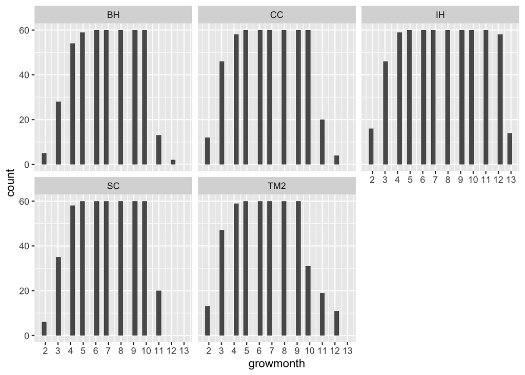

```r
nosnow_grwseason_60 %>% ggplot(aes(x=growmonth)) + geom_histogram() +
  scale_x_continuous(breaks=c(1, 2, 3, 4, 5,6,7,8,9,10, 11, 12, 13)) +
  facet_wrap(~parent.pop)
```

```r
nosnow_grwseason_60 %>% filter(parent.pop=="IH", grow_yr==1965)
```

```
## # A tibble: 11 × 17
## # Groups:   parent.pop, elevation.group, elev_m, grow_yr [1]
##    parent.pop elevation.group elev_m Lat     Long  PckSum year_cal grow_yr month
##    <chr>      <chr>            <dbl> <chr>   <chr>  <dbl>    <int>   <int> <dbl>
##  1 IH         low               454. 39.093… -120…     NA     1964    1965    11
##  2 IH         low               454. 39.093… -120…     NA     1964    1965    12
##  3 IH         low               454. 39.093… -120…     NA     1965    1965     1
##  4 IH         low               454. 39.093… -120…     NA     1965    1965     2
##  5 IH         low               454. 39.093… -120…     NA     1965    1965     3
##  6 IH         low               454. 39.093… -120…     NA     1965    1965     4
##  7 IH         low               454. 39.093… -120…     NA     1965    1965     5
##  8 IH         low               454. 39.093… -120…     NA     1965    1965     6
##  9 IH         low               454. 39.093… -120…     NA     1965    1965     7
## 10 IH         low               454. 39.093… -120…     NA     1965    1965     8
## 11 IH         low               454. 39.093… -120…     NA     1965    1965     9
## # ℹ 8 more variables: growmonth <dbl>, firstmonth <dbl>, lastmonth <dbl>,
## #   cwd <dbl>, pck <dbl>, ppt <dbl>, tmn <dbl>, tmx <dbl>
```

### Populations that get more than 70 mm of snow pack in a year (on average)

- First month = snowpack = 0 and min temp > 0
  - Remember this month is not included in the final “growth season”
- Last month = snowpack. > 70 mm OR pck > 0 and min temp < 0 OR min temp < -5 (moderate freeze)

Note: “The month name of the snowpack file (that is, pckmar.asc) relates to the first day of the next month (that is, station observations on April 1st correlate with the snowpack file for March).” But this makes sense, a survey on April 1 gives a sense for the total snowpack in March.

```r
snow_pops_60 <- pop_elev_climate_60_avgs %>% filter(PckSum >= 70)
unique(snow_pops_60$parent.pop) #18 pops + garden site get some significant snowpack per year
```

```
##  [1] "CP2"        "CP3"        "DPR"        "FR"         "LV1"
##  [6] "LV3"        "LVTR1"      "SQ1"        "SQ2"        "SQ3"
## [11] "WL1"        "WL2"        "WL2_Garden" "WR"         "WV"
## [16] "YO11"       "YO4"        "YO7"        "YO8"
```

```r
#add rest of 2023 calendar year
snow_pop_ids <- snow_pops_60 %>% select(parent.pop) %>% distinct()
snow_pops_2023_cal_year <- pop_elev_climate %>%
  filter(parent.pop != "UCD_Garden") %>%
  mutate(month = recode(month,
  jan = 1,
  feb = 2,
  mar = 3,
  apr = 4,
  may = 5,
  jun = 6,
  jul = 7,
  aug = 8,
  sep = 9,
  oct = 10,
  nov = 11,
  dec = 12
)) %>%
  left_join(growyear_months) %>%
  mutate(grow_yr = year + month %in% c(9:12)) %>%
  select(parent.pop:Long, year_cal=year, grow_yr, month, growmonth, cwd, pck, ppt, tmn, tmx) %>%
  filter(grow_yr == 2024, year_cal==2023) %>%
  right_join(snow_pop_ids)
snow_pops_60_tojoin <- snow_pops_60 %>% select(parent.pop:Long, PckSum) %>% distinct()
snow_pops_60_years <- left_join(snow_pops_60_tojoin, pop_elev_climate_60) %>%
  filter(year_cal >1963) %>%  #remove 1963 calendar year
  bind_rows(snow_pops_2023_cal_year) %>% #add rest of 2023 calendar year
  arrange(parent.pop, year_cal, month)
#first month
snow_60_first_month <- snow_pops_60_years %>%
  group_by(parent.pop, elevation.group, elev_m, Lat, Long, year_cal) %>% #find snow pops growth season within the normal calendar year since they can end as late as December
  filter(pck==0) %>%
  filter(tmn > 0) %>%
  arrange(month) %>%
  filter(row_number()==1) #get first month for each pop and year with no snowpack for germ
snow_60_first_month_tomerge <- snow_60_first_month %>%
  select(parent.pop:Long, year_cal, firstmonth=month)
snow_60_first_month_col <- full_join(snow_pops_60_years, snow_60_first_month_tomerge)
```

```
## year_cal)`
```

```r
#last month
snow_60_last_month <- snow_60_first_month_col %>%
  group_by(parent.pop, elevation.group, elev_m,  Lat, Long, year_cal) %>%
  filter(month>firstmonth) %>%
  filter(month>4) %>% #before adding this, the min last month was 10 (except for cases with Jan germ and Feb snow)
  filter(if_else(pck>70, pck>70,
                 if_else(pck>0, tmn < 0, tmn <= -5))) %>%  #-5 is moderate freeze (Pardee et al. 2017)
  arrange(month) %>%
  filter(row_number()==1) #get first month after growstart for each pop and year with pck >70 OR pck>0 & tmn <0 OR tmn <-5
snow_60_last_month_tomerge <- snow_60_last_month %>%
  select(parent.pop:Long, year_cal, firstmonth,lastmonth=month)
snow_60_last_month_col <- full_join(snow_60_first_month_col, snow_60_last_month_tomerge) %>%
  select(firstmonth, lastmonth, year_cal:tmx)
```

```
## year_cal, firstmonth)`
## `Lat`, `Long`
```

#### Checking for weird cases

```r
snow_60_last_month_col %>% filter(is.na(firstmonth)) #no cases where there isn't a firstmonth
```

```
## # A tibble: 0 × 16
## # Groups:   parent.pop, elevation.group, elev_m, Lat, Long [0]
## # ℹ 16 variables: parent.pop <chr>, elevation.group <chr>, elev_m <dbl>,
## #   Lat <chr>, Long <chr>, firstmonth <dbl>, lastmonth <dbl>, year_cal <int>,
## #   grow_yr <int>, month <dbl>, growmonth <dbl>, cwd <dbl>, pck <dbl>,
## #   ppt <dbl>, tmn <dbl>, tmx <dbl>
```

```r
snow_60_last_month_col %>% filter(lastmonth==firstmonth) %>% arrange(parent.pop, year_cal) #no cases where last month is first month
```

```
## # A tibble: 0 × 16
## # Groups:   parent.pop, elevation.group, elev_m, Lat, Long [0]
## # ℹ 16 variables: parent.pop <chr>, elevation.group <chr>, elev_m <dbl>,
## #   Lat <chr>, Long <chr>, firstmonth <dbl>, lastmonth <dbl>, year_cal <int>,
## #   grow_yr <int>, month <dbl>, growmonth <dbl>, cwd <dbl>, pck <dbl>,
## #   ppt <dbl>, tmn <dbl>, tmx <dbl>
```

```r
snow_60_last_month_col %>% filter(is.na(lastmonth)) #238 cases where there isn't a lastmonth #*no snow_pack, or min temp > -5
```

```
## # A tibble: 2,856 × 16
## # Groups:   parent.pop, elevation.group, elev_m, Lat, Long [15]
##    parent.pop elevation.group elev_m Lat     Long  firstmonth lastmonth year_cal
##    <chr>      <chr>            <dbl> <chr>   <chr>      <dbl>     <dbl>    <int>
##  1 CP2        high             2244. 38.661… -120…          5        NA     1976
##  2 CP2        high             2244. 38.661… -120…          5        NA     1976
##  3 CP2        high             2244. 38.661… -120…          5        NA     1976
##  4 CP2        high             2244. 38.661… -120…          5        NA     1976
##  5 CP2        high             2244. 38.661… -120…          5        NA     1976
##  6 CP2        high             2244. 38.661… -120…          5        NA     1976
##  7 CP2        high             2244. 38.661… -120…          5        NA     1976
##  8 CP2        high             2244. 38.661… -120…          5        NA     1976
##  9 CP2        high             2244. 38.661… -120…          5        NA     1976
## 10 CP2        high             2244. 38.661… -120…          5        NA     1976
## # ℹ 2,846 more rows
## # ℹ 8 more variables: grow_yr <int>, month <dbl>, growmonth <dbl>, cwd <dbl>,
## #   pck <dbl>, ppt <dbl>, tmn <dbl>, tmx <dbl>
```

```r
#***WHAT TO DO FOR THESE CASES? check the next calendar year to see when pck > 70 and make the last month 12 (Dec) for the ones without that #JRG - let's use the max  of last month for these cases.

snow_60_last_month_col %>% filter(lastmonth==firstmonth+1) %>% arrange(parent.pop, year_cal) #0 cases
```

```
## # A tibble: 0 × 16
## # Groups:   parent.pop, elevation.group, elev_m, Lat, Long [0]
## # ℹ 16 variables: parent.pop <chr>, elevation.group <chr>, elev_m <dbl>,
## #   Lat <chr>, Long <chr>, firstmonth <dbl>, lastmonth <dbl>, year_cal <int>,
## #   grow_yr <int>, month <dbl>, growmonth <dbl>, cwd <dbl>, pck <dbl>,
## #   ppt <dbl>, tmn <dbl>, tmx <dbl>
```

```r
snow_60_last_month_col %>% filter(lastmonth==firstmonth+2) #6 cases where there was sig snowpack in the second month after the first month of 0 snowpack
```

```
## # A tibble: 72 × 16
## # Groups:   parent.pop, elevation.group, elev_m, Lat, Long [3]
##    parent.pop elevation.group elev_m Lat     Long  firstmonth lastmonth year_cal
##    <chr>      <chr>            <dbl> <chr>   <chr>      <dbl>     <dbl>    <int>
##  1 LV1        high             2593. 40.474… -121…          8        10     1982
##  2 LV1        high             2593. 40.474… -121…          8        10     1982
##  3 LV1        high             2593. 40.474… -121…          8        10     1982
##  4 LV1        high             2593. 40.474… -121…          8        10     1982
##  5 LV1        high             2593. 40.474… -121…          8        10     1982
##  6 LV1        high             2593. 40.474… -121…          8        10     1982
##  7 LV1        high             2593. 40.474… -121…          8        10     1982
##  8 LV1        high             2593. 40.474… -121…          8        10     1982
##  9 LV1        high             2593. 40.474… -121…          8        10     1982
## 10 LV1        high             2593. 40.474… -121…          8        10     1982
## # ℹ 62 more rows
## # ℹ 8 more variables: grow_yr <int>, month <dbl>, growmonth <dbl>, cwd <dbl>,
## #   pck <dbl>, ppt <dbl>, tmn <dbl>, tmx <dbl>
```

```r
heavysnow_60 <- snow_60_last_month_col %>% filter(lastmonth<=firstmonth+2) %>% filter(month==firstmonth)
summary(heavysnow_60)
```

```
##   parent.pop        elevation.group        elev_m         Lat
##  Length:6           Length:6           Min.   :2354   Length:6
##  Class :character   Class :character   1st Qu.:2414   Class :character
##  Mode  :character   Mode  :character   Median :2593   Mode  :character
##                                        Mean   :2563
##                                        3rd Qu.:2704
##                                        Max.   :2741
##      Long             firstmonth    lastmonth       year_cal       grow_yr
##  Length:6           Min.   :8.0   Min.   :10.0   Min.   :1982   Min.   :1982
##  Class :character   1st Qu.:8.0   1st Qu.:10.0   1st Qu.:1982   1st Qu.:1982
##  Mode  :character   Median :8.5   Median :10.5   Median :1982   Median :1983
##                     Mean   :8.5   Mean   :10.5   Mean   :1982   Mean   :1983
##                     3rd Qu.:9.0   3rd Qu.:11.0   3rd Qu.:1983   3rd Qu.:1984
##                     Max.   :9.0   Max.   :11.0   Max.   :1983   Max.   :1984
##      month       growmonth         cwd             pck         ppt
##  Min.   :8.0   Min.   : 1.0   Min.   :45.70   Min.   :0   Min.   :11.06
##  1st Qu.:8.0   1st Qu.: 1.0   1st Qu.:55.24   1st Qu.:0   1st Qu.:11.30
##  Median :8.5   Median : 6.5   Median :66.81   Median :0   Median :34.41
##  Mean   :8.5   Mean   : 6.5   Mean   :64.21   Mean   :0   Mean   :34.40
##  3rd Qu.:9.0   3rd Qu.:12.0   3rd Qu.:73.01   3rd Qu.:0   3rd Qu.:56.98
##  Max.   :9.0   Max.   :12.0   Max.   :79.47   Max.   :0   Max.   :58.43
##       tmn              tmx
##  Min.   :0.7100   Min.   :17.14
##  1st Qu.:0.7825   1st Qu.:17.34
##  Median :1.3600   Median :18.95
##  Mean   :1.4000   Mean   :18.95
##  3rd Qu.:2.0125   3rd Qu.:20.64
##  Max.   :2.1500   Max.   :20.68
```

```r
unique(heavysnow_60$parent.pop) #3 pops included (all Lassen)
```

```
## [1] "LV1"   "LV3"   "LVTR1"
```

```r
#high snowpack all year except Aug-Nov, these cases are fine to leave

snow_60_last_month_col %>% filter(firstmonth<4) %>% filter(pck>70) %>% filter(month>firstmonth, month<10) #13 cases where Jan or Feb = first month, but high snow 1 or 2 months later
```

```
## # A tibble: 13 × 16
## # Groups:   parent.pop, elevation.group, elev_m, Lat, Long [4]
##    parent.pop elevation.group elev_m Lat     Long  firstmonth lastmonth year_cal
##    <chr>      <chr>            <dbl> <chr>   <chr>      <dbl>     <dbl>    <int>
##  1 DPR        mid              1019. 39.228… -120…          1        NA     1991
##  2 DPR        mid              1019. 39.228… -120…          1        NA     1999
##  3 DPR        mid              1019. 39.228… -120…          1        NA     2019
##  4 DPR        mid              1019. 39.228… -120…          1        NA     2019
##  5 WL1        mid              1614. 38.786… -120…          2        NA     1991
##  6 WL1        mid              1614. 38.786… -120…          1        12     2009
##  7 WL1        mid              1614. 38.786… -120…          1        NA     2018
##  8 WL2        high             2020. 38.8263 -120…          1        12     2014
##  9 WR         mid              1158  39.343… -120…          1        NA     1986
## 10 WR         mid              1158  39.343… -120…          2        NA     1991
## 11 WR         mid              1158  39.343… -120…          1        11     1994
## 12 WR         mid              1158  39.343… -120…          1        NA     2019
## 13 WR         mid              1158  39.343… -120…          1        NA     2019
## # ℹ 8 more variables: grow_yr <int>, month <dbl>, growmonth <dbl>, cwd <dbl>,
## #   pck <dbl>, ppt <dbl>, tmn <dbl>, tmx <dbl>
```

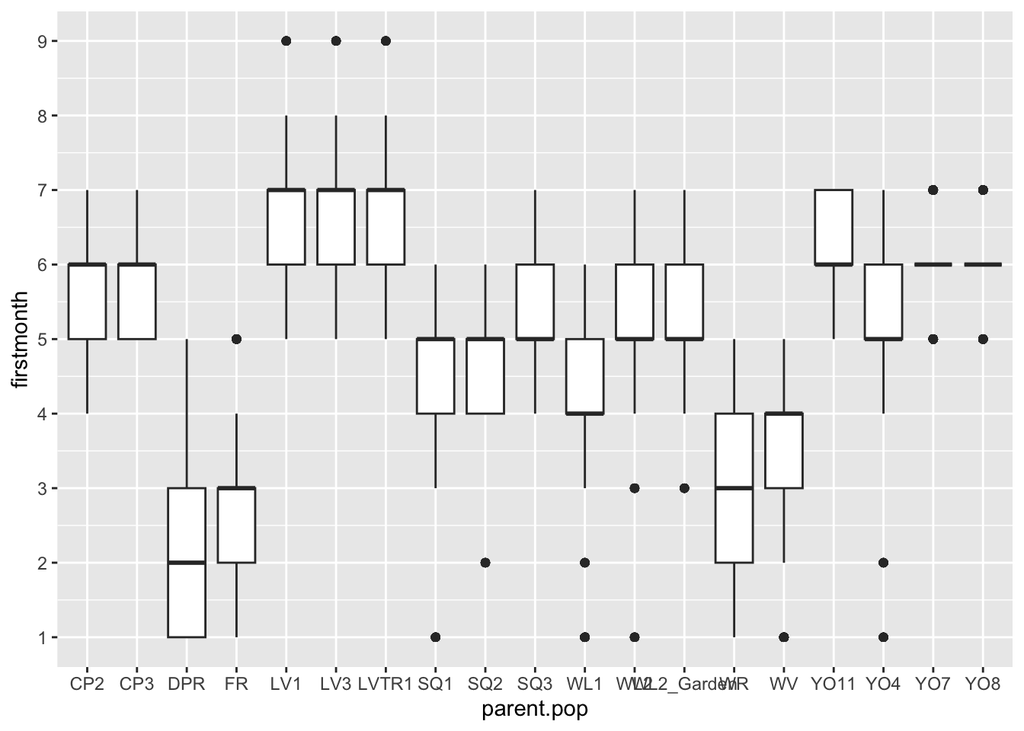

```r
#look at the distribution of start and end months
snow_60_last_month_col %>%
  ggplot(aes(x=parent.pop, y=firstmonth)) +
  geom_boxplot() +
  scale_y_continuous(breaks=c(1, 2, 3, 4, 5,6,7,8,9,10, 11, 12))
```

```r
#Jan and Feb are clearly outliers for some higher elev pops
#SQ1, SQ2, WL1, WL2 (MAR OUTLIER TOO?), WV, YO4
snow_60_last_month_col %>% filter(parent.pop=="SQ1", firstmonth==1) %>%
  filter(pck>70, month>firstmonth, month<10) #no cases of high snowpack soon after germ
```

```
## # A tibble: 0 × 16
## # Groups:   parent.pop, elevation.group, elev_m, Lat, Long [0]
## # ℹ 16 variables: parent.pop <chr>, elevation.group <chr>, elev_m <dbl>,
## #   Lat <chr>, Long <chr>, firstmonth <dbl>, lastmonth <dbl>, year_cal <int>,
## #   grow_yr <int>, month <dbl>, growmonth <dbl>, cwd <dbl>, pck <dbl>,
## #   ppt <dbl>, tmn <dbl>, tmx <dbl>
```

```r
snow_60_last_month_col %>% filter(parent.pop=="SQ2", firstmonth==2) %>%
  filter(pck>70, month>firstmonth, month<10) #no cases of high snowpack soon after germ
```

```
## # A tibble: 0 × 16
## # Groups:   parent.pop, elevation.group, elev_m, Lat, Long [0]
## # ℹ 16 variables: parent.pop <chr>, elevation.group <chr>, elev_m <dbl>,
## #   Lat <chr>, Long <chr>, firstmonth <dbl>, lastmonth <dbl>, year_cal <int>,
## #   grow_yr <int>, month <dbl>, growmonth <dbl>, cwd <dbl>, pck <dbl>,
## #   ppt <dbl>, tmn <dbl>, tmx <dbl>
```

```r
snow_60_last_month_col %>% filter(parent.pop=="WV", firstmonth==1) %>%
  filter(pck>70, month>firstmonth, month<10) #no cases of high snowpack soon after germ
```

```
## # A tibble: 0 × 16
## # Groups:   parent.pop, elevation.group, elev_m, Lat, Long [0]
## # ℹ 16 variables: parent.pop <chr>, elevation.group <chr>, elev_m <dbl>,
## #   Lat <chr>, Long <chr>, firstmonth <dbl>, lastmonth <dbl>, year_cal <int>,
## #   grow_yr <int>, month <dbl>, growmonth <dbl>, cwd <dbl>, pck <dbl>,
## #   ppt <dbl>, tmn <dbl>, tmx <dbl>
```

```r
snow_60_last_month_col %>% filter(parent.pop=="YO4", firstmonth<3) %>%
  filter(pck>70, month>firstmonth, month<10) #no cases of high snowpack soon after germ
```

```
## # A tibble: 0 × 16
## # Groups:   parent.pop, elevation.group, elev_m, Lat, Long [0]
## # ℹ 16 variables: parent.pop <chr>, elevation.group <chr>, elev_m <dbl>,
## #   Lat <chr>, Long <chr>, firstmonth <dbl>, lastmonth <dbl>, year_cal <int>,
## #   grow_yr <int>, month <dbl>, growmonth <dbl>, cwd <dbl>, pck <dbl>,
## #   ppt <dbl>, tmn <dbl>, tmx <dbl>
```

```r
snow_60_last_month_col %>% filter(parent.pop=="WL1", firstmonth<3) %>%
  filter(pck>70, month>firstmonth, month<10) #3 years with high snow pack 1 or 2 months post germ (1991, 2009, 2018)
```

```
## # A tibble: 3 × 16
## # Groups:   parent.pop, elevation.group, elev_m, Lat, Long [1]
##   parent.pop elevation.group elev_m Lat      Long  firstmonth lastmonth year_cal
##   <chr>      <chr>            <dbl> <chr>    <chr>      <dbl>     <dbl>    <int>
## 1 WL1        mid              1614. 38.78608 -120…          2        NA     1991
## 2 WL1        mid              1614. 38.78608 -120…          1        12     2009
## 3 WL1        mid              1614. 38.78608 -120…          1        NA     2018
## # ℹ 8 more variables: grow_yr <int>, month <dbl>, growmonth <dbl>, cwd <dbl>,
## #   pck <dbl>, ppt <dbl>, tmn <dbl>, tmx <dbl>
```

```r
snow_60_last_month_col %>% filter(parent.pop=="WL2", firstmonth<=3) %>%
  filter(pck>70, month>firstmonth, month<10) #1 year with high snow pack 1 month post germ (2014)
```

```
## # A tibble: 1 × 16
## # Groups:   parent.pop, elevation.group, elev_m, Lat, Long [1]
##   parent.pop elevation.group elev_m Lat     Long   firstmonth lastmonth year_cal
##   <chr>      <chr>            <dbl> <chr>   <chr>       <dbl>     <dbl>    <int>
## 1 WL2        high             2020. 38.8263 -120.…          1        12     2014
## # ℹ 8 more variables: grow_yr <int>, month <dbl>, growmonth <dbl>, cwd <dbl>,
## #   pck <dbl>, ppt <dbl>, tmn <dbl>, tmx <dbl>
```

```r
#Check with J&J about the above WL1 and WL2 cases, for now just leave them in
```

#### Deal with weird cases

```r
#search for the last month in the grow year rather than calendar year for the cases without a last month
snow_60_last_month_grwyr <- snow_60_last_month_col %>%
  filter(month<9) %>%
  group_by(parent.pop, elevation.group, elev_m,  Lat, Long, grow_yr) %>%
  filter(if_else(pck>70, pck>70,
                 if_else(pck>0, tmn < 0, tmn <= -5))) %>%  #-5 is moderate freeze (Pardee et al. 2017)
  arrange(growmonth) %>%
  filter(row_number()==1)
snow_60_last_month_grwyr_tomerge <- snow_60_last_month_grwyr %>%
  ungroup() %>%
  mutate(year_cal=grow_yr-1) %>% #will apply these last months to the previous cal year
  select(parent.pop:Long, year_cal,lastmonth_grwyr=growmonth) %>%
  arrange(parent.pop, year_cal)
snow_60_last_grw_month_col <- left_join(snow_60_last_month_col, snow_60_last_month_grwyr_tomerge) %>%
  select(firstmonth, lastmonth, lastmonth_grwyr, year_cal:tmx)
```

```
## year_cal)`
## `Lat`, `Long`
```

```r
snow_60_last_grw_month_col %>% filter(is.na(lastmonth), is.na(lastmonth_grwyr)) #still some with no last month - use the max last month for these
```

```
## # A tibble: 1,020 × 17
## # Groups:   parent.pop, elevation.group, elev_m, Lat, Long [9]
##    parent.pop elevation.group elev_m Lat      Long       firstmonth lastmonth
##    <chr>      <chr>            <dbl> <chr>    <chr>           <dbl>     <dbl>
##  1 DPR        mid              1019. 39.22846 -120.81518          5        NA
##  2 DPR        mid              1019. 39.22846 -120.81518          5        NA
##  3 DPR        mid              1019. 39.22846 -120.81518          5        NA
##  4 DPR        mid              1019. 39.22846 -120.81518          5        NA
##  5 DPR        mid              1019. 39.22846 -120.81518          5        NA
##  6 DPR        mid              1019. 39.22846 -120.81518          5        NA
##  7 DPR        mid              1019. 39.22846 -120.81518          5        NA
##  8 DPR        mid              1019. 39.22846 -120.81518          5        NA
##  9 DPR        mid              1019. 39.22846 -120.81518          5        NA
## 10 DPR        mid              1019. 39.22846 -120.81518          5        NA
## # ℹ 1,010 more rows
## # ℹ 10 more variables: lastmonth_grwyr <dbl>, year_cal <dbl>, grow_yr <int>,
## #   month <dbl>, growmonth <dbl>, cwd <dbl>, pck <dbl>, ppt <dbl>, tmn <dbl>,
## #   tmx <dbl>
```

```r
snow_60_last_grw_month_col %>% group_by(parent.pop) %>% summarise(maxEnd=max(lastmonth, na.rm = TRUE)) #max end for every pop = 12
```

```
## # A tibble: 19 × 2
##    parent.pop maxEnd
##    <chr>       <dbl>
##  1 CP2            12
##  2 CP3            12
##  3 DPR            12
##  4 FR             12
##  5 LV1            12
##  6 LV3            12
##  7 LVTR1          12
##  8 SQ1            12
##  9 SQ2            12
## 10 SQ3            12
## 11 WL1            12
## 12 WL2            12
## 13 WL2_Garden     12
## 14 WR             12
## 15 WV             12
## 16 YO11           12
## 17 YO4            12
## 18 YO7            12
## 19 YO8            12
```

```r
snow_60first_last_month <- snow_60_last_grw_month_col %>%
  mutate(lastmonth=if_else(is.na(lastmonth) & is.na(lastmonth_grwyr), 12,#assign the max end
                           lastmonth))

snow_60_last_grw_month_col %>% filter(is.na(lastmonth), !is.na(lastmonth_grwyr)) #use the grow year last month for these
```

```
## # A tibble: 1,836 × 17
## # Groups:   parent.pop, elevation.group, elev_m, Lat, Long [15]
##    parent.pop elevation.group elev_m Lat      Long       firstmonth lastmonth
##    <chr>      <chr>            <dbl> <chr>    <chr>           <dbl>     <dbl>
##  1 CP2        high             2244. 38.66169 -120.13065          5        NA
##  2 CP2        high             2244. 38.66169 -120.13065          5        NA
##  3 CP2        high             2244. 38.66169 -120.13065          5        NA
##  4 CP2        high             2244. 38.66169 -120.13065          5        NA
##  5 CP2        high             2244. 38.66169 -120.13065          5        NA
##  6 CP2        high             2244. 38.66169 -120.13065          5        NA
##  7 CP2        high             2244. 38.66169 -120.13065          5        NA
##  8 CP2        high             2244. 38.66169 -120.13065          5        NA
##  9 CP2        high             2244. 38.66169 -120.13065          5        NA
## 10 CP2        high             2244. 38.66169 -120.13065          5        NA
## # ℹ 1,826 more rows
## # ℹ 10 more variables: lastmonth_grwyr <dbl>, year_cal <dbl>, grow_yr <int>,
## #   month <dbl>, growmonth <dbl>, cwd <dbl>, pck <dbl>, ppt <dbl>, tmn <dbl>,
## #   tmx <dbl>
```

```r
snow_no_end <- snow_60first_last_month %>%
  filter(is.na(lastmonth)) %>%
  select(-lastmonth)
snow_no_end_nextyr <- snow_no_end %>%
  filter(grow_yr>year_cal) %>% #want the next calendar year
  ungroup() %>%
  select(parent.pop, year_cal=grow_yr, firstmonth, lastmonth_grwyr) %>%
  distinct() %>%
  left_join(pop_elev_climate_60) %>%
  filter(growmonth>4) %>% #want only Jan +
  filter(growmonth<=lastmonth_grwyr) %>% #only keep the rows for the months between Jan and whatever the end month is in growthmonth format
  mutate(year_cal=year_cal-1, #change the calendar year to the previous
         month=month+12, #change the month number appropriately
          lastmonth=(lastmonth_grwyr-4)+12)
snow_no_end_nextyr_lastmonth <- snow_no_end_nextyr %>%
  select(parent.pop, year_cal, lastmonth) %>%
  distinct() %>%
  left_join(snow_no_end) #add last month info to snow_no_end
#snow_no_end_nextyr
#snow_60_last_grw_month_col %>% filter(parent.pop=="CP2", year_cal>1975) #the above code worked!
```

#### Fill in all the months b/t the first and last

```r
snow_no_end_last_month_fixed <- snow_no_end_nextyr_lastmonth %>%
  bind_rows(snow_no_end_nextyr) %>% #add rows for additional months in
  arrange(year_cal, month) %>%
  select(-growmonth) %>% #remove this since we lost it on the new rows
  group_by(parent.pop, elevation.group, elev_m,  Lat, Long,  year_cal) %>%
  filter(month>firstmonth) %>%
  filter(month<=lastmonth) %>%
  arrange(parent.pop, year_cal, month)

snow_grwseason_60 <- snow_60first_last_month %>%
  group_by(parent.pop, elevation.group, elev_m,  Lat, Long, year_cal) %>%
  filter(month>firstmonth) %>%
  filter(month<=lastmonth) %>%
  bind_rows(snow_no_end_last_month_fixed) %>%
  arrange(parent.pop, year_cal, month) %>%
  select(parent.pop:Long, firstmonth, lastmonth, year_cal:month, cwd:tmx)

xtabs(~parent.pop+month, data=snow_grwseason_60)
```

```
##             month
## parent.pop    2  3  4  5  6  7  8  9 10 11 12 13 14 15
##   CP2         0  0  0  1 27 51 60 60 60 60 33  4  0  0
##   CP3         0  0  0  0 18 49 60 60 60 60 31  1  0  0
##   DPR        21 36 50 58 60 60 60 60 60 60 60 17  7  2
##   FR          8 21 47 58 60 60 60 60 60 60 59 17  8  1
##   LV1         0  0  0  0  2 28 53 59 60 55  5  0  0  0
##   LV3         0  0  0  0  2 28 53 59 60 55  4  0  0  0
##   LVTR1       0  0  0  0  2 28 53 59 60 55  3  0  0  0
##   SQ1         2  2  3 23 55 60 60 60 60 60 52 15  3  1
##   SQ2         0  1  1 19 53 60 60 60 60 60 52 15  3  1
##   SQ3         0  0  0  1 34 54 60 60 60 60 43 10  1  0
##   WL1         5  6 12 31 59 60 60 60 60 60 53 11  5  1
##   WL2         1  1  2  9 34 58 60 60 60 60 39 10  2  0
##   WL2_Garden  0  0  1  7 34 58 60 60 60 60 38 10  2  0
##   WR         12 17 33 51 60 60 60 60 60 60 57 17  5  1
##   WV          4 12 28 53 60 60 60 60 60 60 59 13  1  0
##   YO11        0  0  0  0  2 40 60 60 60 56 11  0  0  0
##   YO4         1  2  2 11 37 59 60 60 60 60 40 11  2  0
##   YO7         0  0  0  0 11 48 60 60 60 60 30  1  0  0
##   YO8         0  0  0  0  5 46 60 60 60 60 23  1  0  0
```

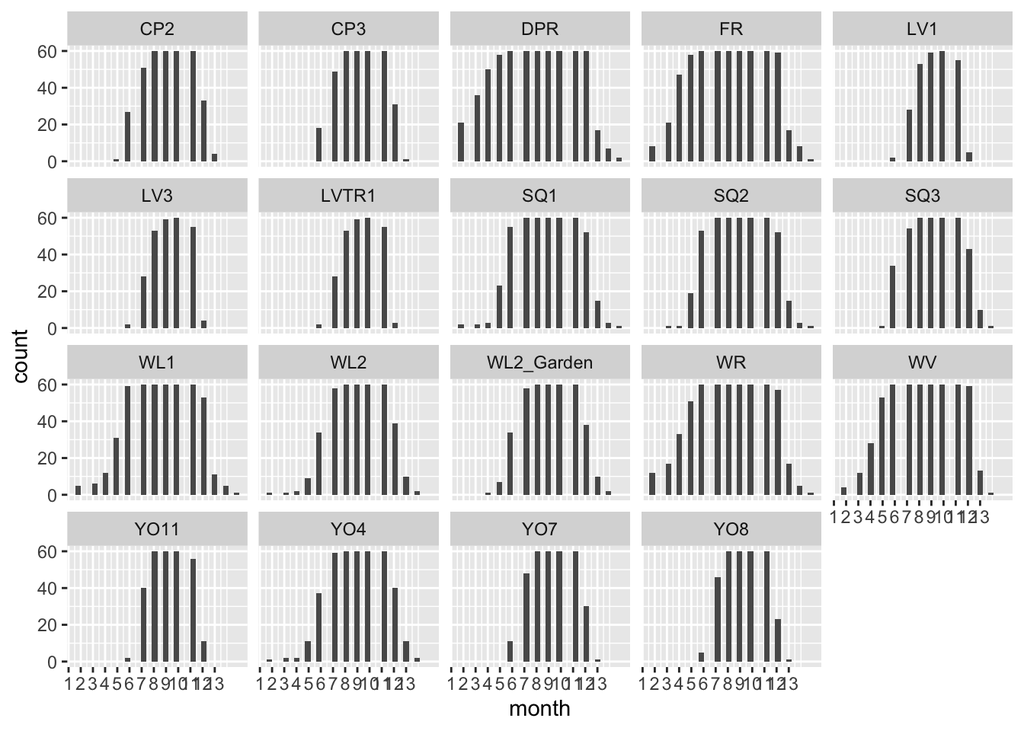

```r
snow_grwseason_60 %>% ggplot(aes(x=month)) + geom_histogram() +
  scale_x_continuous(breaks=c(1, 2, 3, 4, 5,6,7,8,9,10, 11, 12,13)) +
  facet_wrap(~parent.pop)
```

### WL2 Garden 2024 Growth Season Climate

Calculate this separately so it’s not included in the 60 year summary stats

```r
WL2_2024_clim <- pop_elev_climate %>%
  filter(parent.pop == "WL2_Garden") %>%
  mutate(month = recode(month, #convert months to numbers
  jan = 1,
  feb = 2,
  mar = 3,
  apr = 4,
  may = 5,
  jun = 6,
  jul = 7,
  aug = 8,
  sep = 9,
  oct = 10,
  nov = 11,
  dec = 12
)) %>%
  filter(year==2024) %>%
  select(parent.pop:Long, year_cal=year, month, cwd, pck, ppt, tmn, tmx) %>%
  arrange(year_cal, month)

#first month
WL2_2024_first_month <- WL2_2024_clim %>%
  group_by(parent.pop, elevation.group, elev_m,  Lat, Long, year_cal) %>% #need to group here so that "row_number()==1" will get the first month for each pop, not just the first pop in the data frame
  filter(pck==0) %>%
  filter(tmn > 0) %>%
  arrange(month) %>%
  filter(row_number()==1) #get first month for each pop and year with no snowpack for germ
WL2_2024_first_month_tomerge <- WL2_2024_first_month %>%
  select(parent.pop:Long, year_cal, firstmonth=month)
WL2_2024_first_month_col <- full_join(WL2_2024_clim, WL2_2024_first_month_tomerge)
```

```
## year_cal)`
```

```r
#last month
WL2_2024_last_month <- WL2_2024_first_month_col %>%
  group_by(parent.pop, elevation.group, elev_m,  Lat, Long, year_cal) %>%
  filter(month>firstmonth) %>%
  #filter(month>4) %>% #before adding this, the min last month was 10 (except for cases with Jan germ and Feb snow)
  filter(if_else(pck>70, pck>70,
                 if_else(pck>0, tmn < 0, tmn <= -5))) %>%  #-5 is moderate freeze (Pardee et al. 2017)
  arrange(month) %>%
  filter(row_number()==1) #get first month after growstart for each pop and year with pck >70 OR pck>0 & tmn <0 OR tmn <-5
WL2_2024_last_month_tomerge <- WL2_2024_last_month %>%
  select(parent.pop:Long, year_cal, firstmonth,lastmonth=month)
WL2_2024_last_month_col <- full_join(WL2_2024_first_month_col, WL2_2024_last_month_tomerge) %>%
  select(parent.pop, elevation.group, elev_m, Lat, Long, firstmonth, lastmonth, year_cal:tmx)
```

```
## year_cal, firstmonth)`
```

```r
#first month = 5, last month = 11

#filter growth season months only
WL2_2024_grwssn <- WL2_2024_last_month_col %>%
  group_by(parent.pop, elevation.group, elev_m,  Lat, Long, year_cal) %>%
  filter(month>firstmonth) %>%
  filter(month<=lastmonth) %>%
  arrange(parent.pop, year_cal, month) %>%
  select(parent.pop:Long, firstmonth, lastmonth, year_cal:month, cwd:tmx)
```

## Flint for growing season months only

Bind snow and no_snow pops together

```r
nosnow_grwseason_60_prep <- nosnow_grwseason_60 %>%
  select(parent.pop:Long, year=grow_yr, #grow season months in grow year format for no snow pops
         month, firstmonth:tmx)
snow_grwseason_60_prep <- snow_grwseason_60 %>%
  select(parent.pop:Long, year=year_cal, #grow season months in calendar year format for snow pops
         firstmonth:lastmonth, month:tmx)
WL2_2024_grwssn_prep <- WL2_2024_grwssn %>%
  select(parent.pop:Long, year=year_cal,
         firstmonth:lastmonth, month:tmx)
WL2_2023_July <- pop_elev_climate %>%
  filter(parent.pop=="WL2_Garden", month=="jul", year==2023) %>% #add July 2023 back in
  mutate(month=7) %>%
  select(parent.pop:Long, year, month, cwd, pck, ppt, tmn, tmx)

flint_60_grwseason <- rbind(nosnow_grwseason_60_prep, snow_grwseason_60_prep) %>%
  bind_rows(WL2_2024_grwssn_prep) %>%
  bind_rows(WL2_2023_July) %>%
  mutate(timeframe = case_when(
                                year >= 1964 & year < 1994 ~ "historic",
                                year >= 1994 & year < 2024 ~ "recent")) %>%
  mutate(grwssn_length = lastmonth-firstmonth) %>%
  select(parent.pop:Long, timeframe, year, month,grwssn_length, cwd:tmx) #organize the columns
summary(flint_60_grwseason)
```

```
##   parent.pop        elevation.group        elev_m           Lat
##  Length:10183       Length:10183       Min.   : 313.0   Length:10183
##  Class :character   Class :character   1st Qu.: 748.9   Class :character
##  Mode  :character   Mode  :character   Median :1613.8   Mode  :character
##                                        Mean   :1483.4
##                                        3rd Qu.:2244.1
##                                        Max.   :2872.3
##
##      Long            timeframe              year          month
##  Length:10183       Length:10183       Min.   :1964   Min.   : 1.000
##  Class :character   Class :character   1st Qu.:1980   1st Qu.: 6.000
##  Mode  :character   Mode  :character   Median :1994   Median : 8.000
##                                        Mean   :1994   Mean   : 7.962
##                                        3rd Qu.:2009   3rd Qu.:10.000
##                                        Max.   :2024   Max.   :15.000
##
##  grwssn_length        cwd              pck              ppt
##  Min.   : 2.00   Min.   :  0.00   Min.   :  0.00   Min.   :  0.00
##  1st Qu.: 6.00   1st Qu.: 28.06   1st Qu.:  0.00   1st Qu.:  5.08
##  Median : 8.00   Median : 56.82   Median :  0.00   Median : 31.51
##  Mean   : 7.69   Mean   : 59.18   Mean   : 13.05   Mean   : 78.28
##  3rd Qu.: 9.00   3rd Qu.: 86.47   3rd Qu.:  0.00   3rd Qu.:108.39
##  Max.   :14.00   Max.   :183.92   Max.   :882.99   Max.   :894.02
##  NA's   :1
##       tmn               tmx
##  Min.   :-11.170   Min.   :-0.10
##  1st Qu.:  1.450   1st Qu.:12.88
##  Median :  5.280   Median :18.99
##  Mean   :  5.205   Mean   :18.69
##  3rd Qu.:  9.280   3rd Qu.:24.04
##  Max.   : 19.740   Max.   :37.21
##
```

```r
unique(flint_60_grwseason$parent.pop)
```

```
##  [1] "BH"         "CC"         "IH"         "SC"         "TM2"
##  [6] "CP2"        "CP3"        "DPR"        "FR"         "LV1"
## [11] "LV3"        "LVTR1"      "SQ1"        "SQ2"        "SQ3"
## [16] "WL1"        "WL2"        "WL2_Garden" "WR"         "WV"
## [21] "YO11"       "YO4"        "YO7"        "YO8"
```

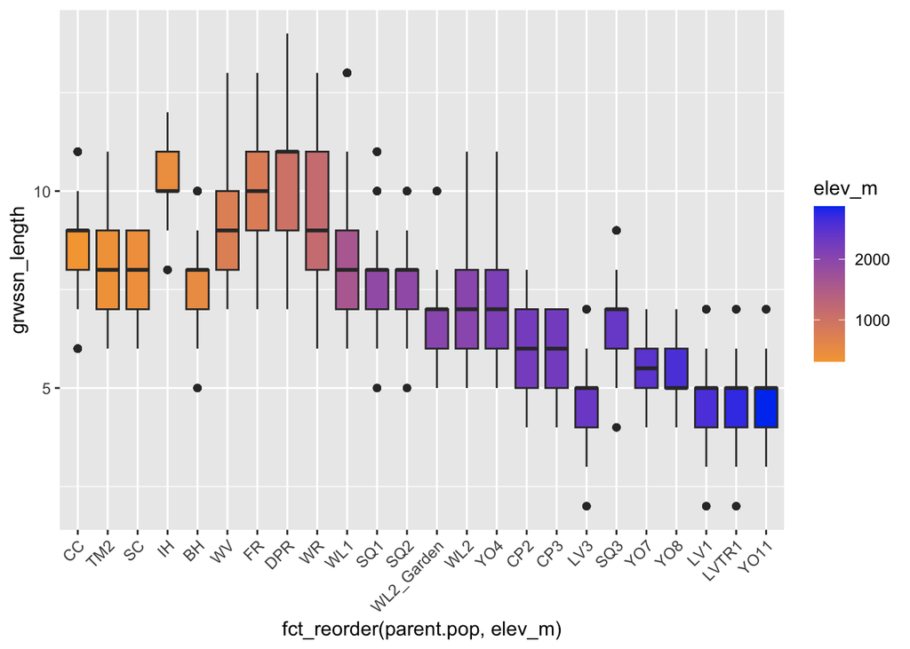

```r
flint_60_grwseason %>%
  ggplot(aes(x=fct_reorder(parent.pop, elev_m), y=grwssn_length, fill = elev_m)) +
  geom_boxplot() +
  scale_fill_gradient(low = "#F5A540", high = "#0043F0") +
  theme(axis.text.x = element_text(angle = 45,  hjust = 1))
```

```r
write_csv(flint_60_grwseason, "../output/Climate/flint_climate_growthseason_60.csv")
```

## Bioclim growing season calculations

Can’t calculate with the function in QBMS for calculating it because I only want it for the growth season, which for most populations is less than 12 months. https://search.r-project.org/CRAN/refmans/QBMS/html/calc_biovars.html

Adapted from Brandie’s BioClim_Growth_Season.Rmd

```r
# Calculating average temp and diurnal range for each month
bioclim_60_meantemp_prep <- flint_60_grwseason %>%
  mutate(tavg = (tmn + tmx)/2, t_diurnal = (tmx-tmn))

# Bio 1, 2, 4, 7, 12, 15
bioclim_60_calc <- bioclim_60_meantemp_prep %>%
  group_by(parent.pop, elevation.group, elev_m,  Lat, Long, year) %>%
  summarise(ann_tmean=mean(tavg),  #Bio1 - Annual Mean Temperature
            mean_diurnal_range=mean(t_diurnal), #Bio2 - Mean Diurnal Range
            temp_seasonality=sd(tavg), #Bio4 - Temperature Seasonality
            temp_ann_range=(max(tmx))-(min(tmn)), #bio7 - temp annual range
            ann_ppt=sum(ppt), #bio12 - annual precip
            ppt_seasonality=cv(ppt+1)) #bio15 - Precipitation Seasonality (+1 to avoid strange CVs for areas where mean rainfaill is < 1)
```

```
## 'Lat', 'Long'. You can override using the `.groups` argument.
```

```r
# Calculating wettest, driest, warmest, and coldest months
wettest_month <- bioclim_60_meantemp_prep %>%  #there's one wettest month per pop/year
  group_by(parent.pop, elevation.group, elev_m, Lat, Long, timeframe, year) %>%
  slice_max(ppt)
driest_month <- bioclim_60_meantemp_prep %>%  #there's more than one driest month for some pops and years
  group_by(parent.pop, elevation.group, elev_m,  Lat, Long, timeframe, year) %>%
  slice_min(ppt)
warmest_month <- bioclim_60_meantemp_prep %>% #there's one warmest month per pop/year
  group_by(parent.pop, elevation.group, elev_m,  Lat, Long, timeframe, year) %>%
  slice_max(tavg)
coldest_month <- bioclim_60_meantemp_prep %>% #there's one coldest month per pop/year
  group_by(parent.pop, elevation.group, elev_m,  Lat, Long, timeframe, year) %>%
  slice_min(tavg)

# Bio 8, 9, 18, 19
bio8_60 <- wettest_month %>% #bio8 = tmean_wettest_month
  dplyr::select(parent.pop, elevation.group, elev_m,  Lat, Long, year, tmean_wettest_month=tavg)
bio9_60 <- driest_month %>% #bio9 = tmean_driest_month
  group_by(parent.pop, elevation.group, elev_m,  Lat, Long, year) %>%
  summarise(tmean_driest_month=mean(tavg)) #taking the average b/c some years where there are multiple driest months
```

```
## 'Lat', 'Long'. You can override using the `.groups` argument.
```

```r
bio18_60 <- warmest_month %>% #bio18 = ppt_warmest_month
  dplyr::select(parent.pop, elevation.group, elev_m,  Lat, Long, year, ppt_warmest_month=ppt)
bio19_60 <- coldest_month %>% #bio19 = ppt_coldest_month
  dplyr::select(parent.pop, elevation.group, elev_m,  Lat, Long, year, ppt_coldest_month=ppt)
# Merge:
bio8_9_60 <- full_join(bio8_60, bio9_60)
```

```
## year)`
```

```r
bio18_19_60 <- full_join(bio18_60, bio19_60)
```

```
## Long, year)`
```

```r
all_periods_60 <- full_join(bio8_9_60, bio18_19_60)
```

```
## Long, year)`
```

```r
# Merge all bioclims:
bioclim_60_grwseason <- full_join(bioclim_60_calc, all_periods_60)
```

```
## year)`
```

```r
write_csv(bioclim_60_grwseason, "../output/Climate/BioClim_growthseason_60.csv")
```

## Merge water year and growing season

```r
#flint_all_year_wtr_yr  #flint water year climate data frame with all years and months + both garden sites
#bioclim_wtryr          #bioclim water year climate data frame with all years + both garden sites
#flint_60_grwseason     #flint growth season climate data frame with most recent 60 years and grow months + WL2 garden
#bioclim_60_grwseason   #bioclim water year climate data frame with most recent 60 years + WL2 garden

#summarize flint by year to merge it with the bioclim data
flint_yrly_avgs_wtr_yr <- flint_all_year_wtr_yr %>%
  filter(timeframe!="beforehistoric", parent.pop!="UCD_Garden") %>%
  rename(year=wtr_yr, year_cal=year) %>%
  group_by(parent.pop, elevation.group, elev_m, Lat, Long, timeframe, year) %>%
  summarise_at(c("cwd", "pck", "ppt", "tmn", "tmx"), c(mean), na.rm = TRUE)

flint_yrly_avgs_grwssn <- flint_60_grwseason %>%
  group_by(parent.pop, elevation.group, elev_m, Lat, Long,  timeframe, year) %>%
  summarise_at(c("cwd", "pck", "ppt", "tmn", "tmx"), c(mean), na.rm = TRUE)

#subset bioclim water year
bioclim_wtryr_to_merge <- bioclim_wtryr %>%
  filter(timeframe!="beforehistoric", parent.pop!="UCD_Garden") %>%
  rename(year=wtr_yr)

#merge
wtr_yr_clim <- left_join(flint_yrly_avgs_wtr_yr, bioclim_wtryr_to_merge) %>% mutate(Season="Water Year")
```

```
## year)`
```

```r
grwssn_clim <- left_join(flint_yrly_avgs_grwssn, bioclim_60_grwseason) %>% mutate(Season="Growth Season")
```

```
## timeframe, year)`
```

```r
all_clim <- bind_rows(wtr_yr_clim, grwssn_clim)
write_csv(all_clim, "../output/Climate/All_Clim.csv")
```